# Advantage of two scans in small populations demonstrated with a transgender dataset.

```r
kable(cbind(names(data.hyp[,bg.avg:nd.avg]), round(pancorr.avg, 3)))
```

| Tavg_L_fusiform_volume | 0 |
| --- | --- |
| Tavg_L_inferiorparietal_volume | 0.005 |
| Tavg_L_postcentral_volume | 0.005 |
| Tavg_L_precentral_volume | 0.128 |
| Tavg_L_frontalpole_volume | 0.101 |
| Tavg_R_fusiform_volume | 0.001 |
| Tavg_R_inferiorparietal_volume | 0.004 |
| Tavg_R_postcentral_volume | 0.049 |
| Tavg_R_precentral_volume | 0.01 |
| Tavg_R_frontalpole_volume | 0.003 |
| Tavg_LeftCerebellumWhiteMatter | 0.004 |
| Tavg_LeftCerebellumCortex | 0 |
| Tavg_RightCerebellumWhiteMatter | 0.003 |
| Tavg_RightCerebellumCortex | 0 |
| Tavg_LeftThalamusProper | 0 |
| Tavg_LeftCaudate | 0.005 |
| Tavg_LeftPutamen | 0.001 |
| Tavg_LeftAccumbensarea | 0.387 |
| Tavg_RightThalamusProper | 0 |
| Tavg_RightCaudate | 0.008 |
| Tavg_RightPutamen | 0.002 |
| Tavg_RightAccumbensarea | 0.014 |

Why are there less regions for which the difference is statistically significant when the average is used compared to when one measure is used? To investigate this we look at the difference between the boxplots for one statistically significant region.

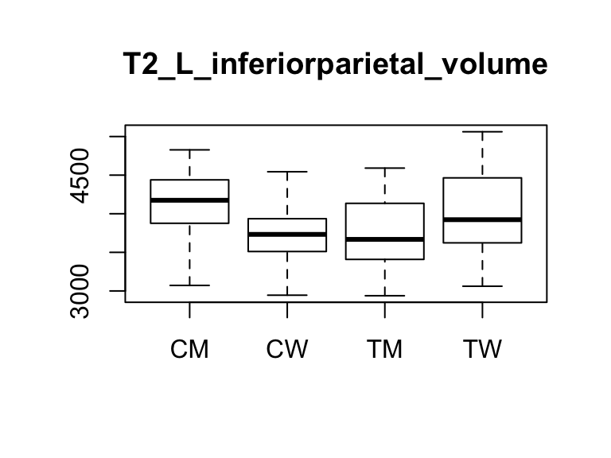

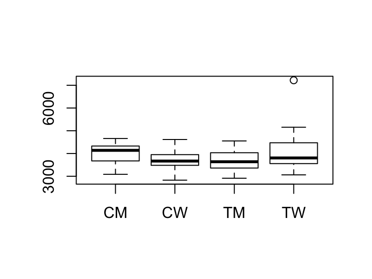

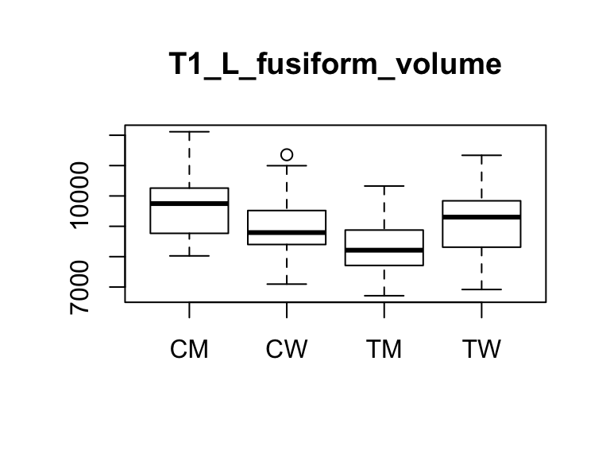

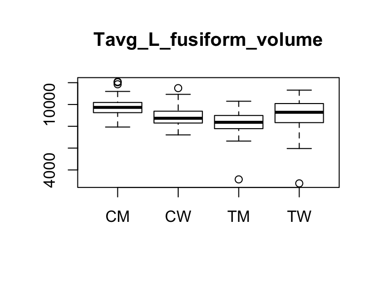

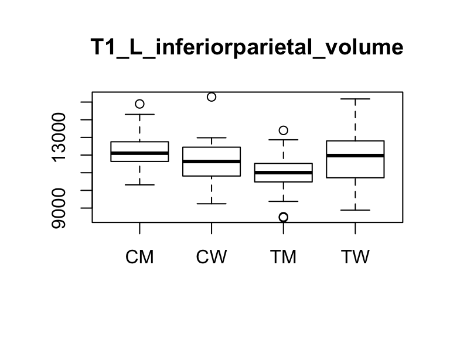

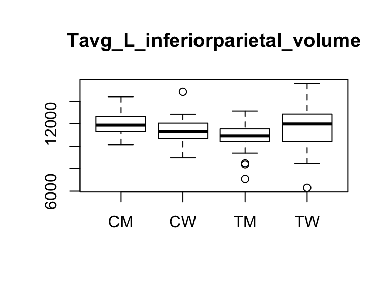

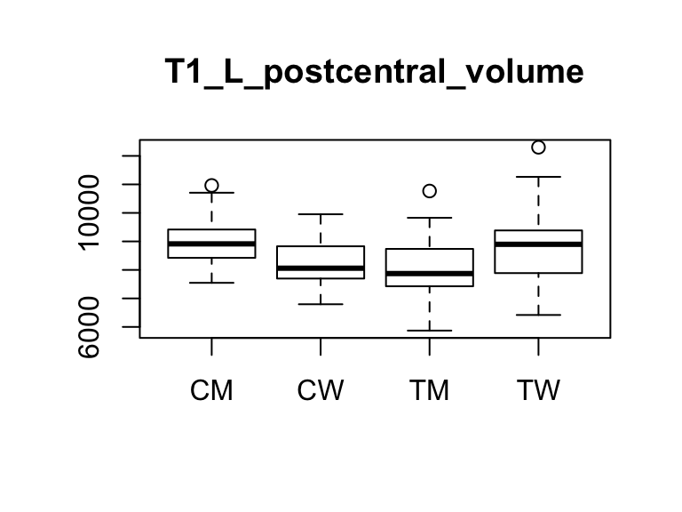

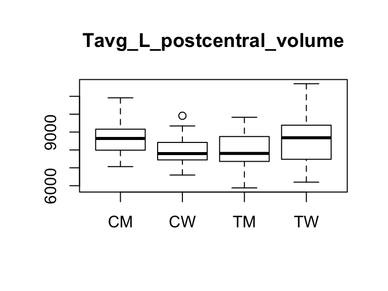

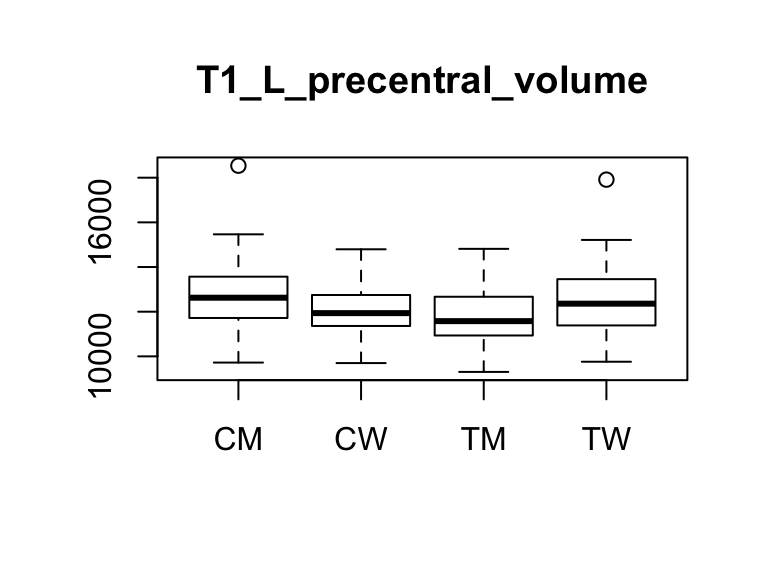

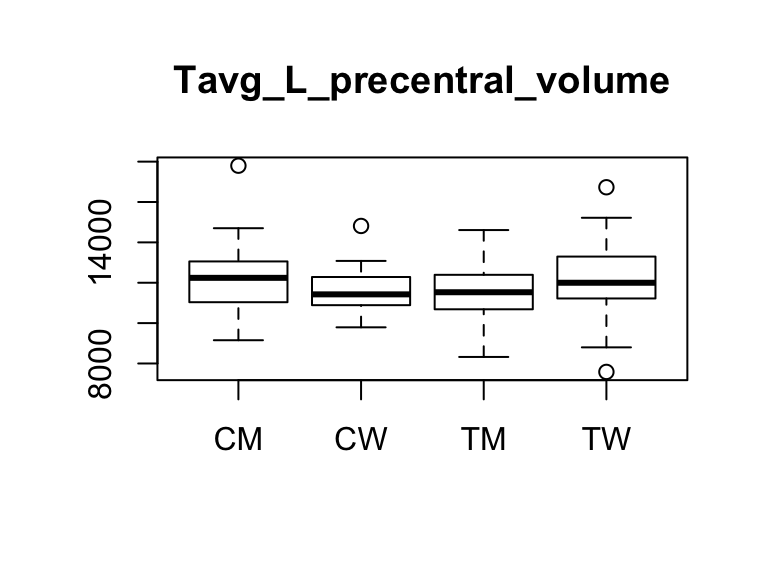

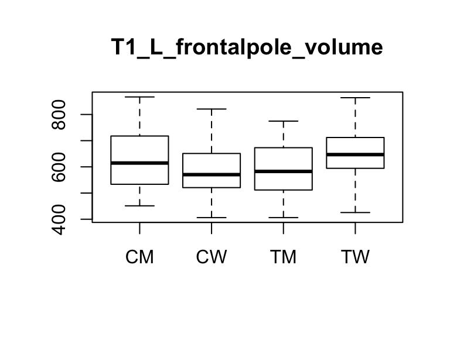

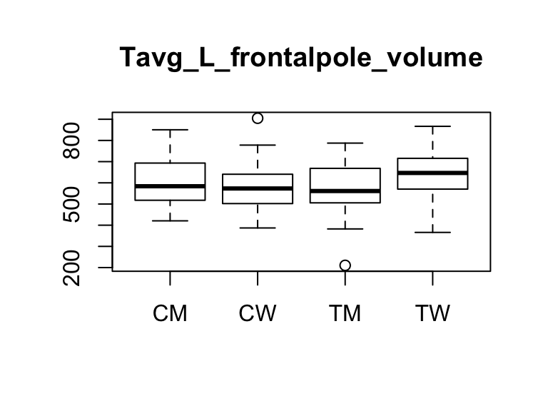

[34 more figures not shown]

```r
boxplot(data.hyp[,22] ~ fac, main = names(data.hyp)[26])
boxplot(data.hyp[,66] ~ fac, main = names(data.hyp)[78])

for(i in bg.one:nd.one){
  # construct boxplot for every region
  boxplot(data.hyp[,i] ~ fac, main = names(data.hyp)[i])
  boxplot(data.hyp[,i + 44] ~ fac, main = names(data.hyp)[i + 44])
}
```

### Post-hoc tests

```r
# create an object with all possible combinations
  allcomb <- combn(c(1:4),2)
  allcomb.txt <- array(data=NA, dim = dim(allcomb)[2])
  labels.g <- c("CW", "CM", "TM", "TW")
  for(i in 1:dim(allcomb)[2]){
    allcomb.txt[i] <- paste(labels.g[allcomb[1,i]], " vs ", labels.g[allcomb[2,i]], sep="")
  }


# create object to save results
  pt.one <- array(data = NA, dim = c(length(pan.one),dim(allcomb)[2]))
  pt.avg <- array(data = NA, dim = c(length(pan.avg),dim(allcomb)[2]))

# Left Cerebellum White Matter
  # 1 measure
  bg.one <- 3
  nd.one <- 24
  pt.corr.one <- array(data=NA, dim=dim(pt.one))
  for(r in bg.one:nd.one){
    if (pan.one[r-bg.one+1] > 0.05) {
        pt.one[r-bg.one+1,] <- rep(NA,dim(allcomb)[2])
    }else{
      for(i in 1:dim(allcomb)[2]){
        pt.one[r-bg.one+1,i] <- unlist(t.test(data.hyp[data.hyp[,2]==allcomb[1,i],r], data.hyp[data.hyp[,2]==allcomb[2,i],r])[3])
        pt.corr.one[r - bg.one + 1,] <- p.adjust(pt.one[r - bg.one + 1,], method = "bonferroni")
      }
    }
  }

  kable(cbind(c(" ",names(data.hyp[,bg.one:nd.one])),rbind(c("CW vs CM","CW vs TM","CW vs TW","CM vs TM","CM vs TW","TM vs TW"),round(pt.corr.one,3))))
```

|  | CW vs CM | CW vs TM | CW vs TW | CM vs TM | CM vs TW | TM vs TW |
| --- | --- | --- | --- | --- | --- | --- |
| T1_L_fusiform_volume | 0.014 | 0.047 | 1 | 0 | 0.202 | 0.001 |
| T1_L_inferiorparietal_volume | 0.137 | 0.158 | 1 | 0 | 0.949 | 0.025 |
| T1_L_postcentral_volume | 0.01 | 1 | 0.233 | 0.002 | 1 | 0.06 |
| T1_L_precentral_volume | 0.284 | 1 | 0.807 | 0.087 | 1 | 0.243 |
| T1_L_frontalpole_volume | 0.929 | 1 | 0.015 | 0.998 | 1 | 0.009 |
| T1_R_fusiform_volume | 0.013 | 0.02 | 1 | 0 | 0.78 | 0.006 |
| T1_R_inferiorparietal_volume | 0.162 | 0.568 | 1 | 0.001 | 1 | 0.006 |
| T1_R_postcentral_volume | 0.87 | 1 | 0.534 | 0.067 | 1 | 0.018 |
| T1_R_precentral_volume | 0.014 | 1 | 0.026 | 0.034 | 1 | 0.087 |
| T1_R_frontalpole_volume | 0.004 | 1 | 0.624 | 0.005 | 0.177 | 0.724 |
| T1_LeftCerebellumWhiteMatter | 0.036 | 0.775 | 1 | 0 | 0.01 | 0.677 |
| T1_LeftCerebellumCortex | 0.005 | 0.587 | 0.009 | 0 | 1 | 0 |
| T1_RightCerebellumWhiteMatter | 0.04 | 1 | 1 | 0.001 | 0.133 | 0.221 |
| T1_RightCerebellumCortex | 0.003 | 0.227 | 0.058 | 0 | 1 | 0 |
| T1_LeftThalamusProper | 0.004 | 0.196 | 0.61 | 0 | 0.174 | 0.002 |
| T1_LeftCaudate | 0.021 | 1 | 0.072 | 0.02 | 1 | 0.066 |
| T1_LeftPutamen | 0.14 | 1 | 0.417 | 0.032 | 1 | 0.069 |
| T1_LeftAccumbensarea | NA | NA | NA | NA | NA | NA |
| T1_RightThalamusProper | 0.127 | 0.047 | 1 | 0 | 0.775 | 0.004 |
| T1_RightCaudate | 0.003 | 1 | 0.124 | 0.007 | 1 | 0.203 |
| T1_RightPutamen | 0 | 1 | 0.002 | 0.001 | 1 | 0.03 |
| T1_RightAccumbensarea | NA | NA | NA | NA | NA | NA |

```r
  # Average
  bg.avg <- 47
  nd.avg <- 68
  pt.corr.avg <- array(data=NA, dim=dim(pt.avg))
  for(r in bg.avg:nd.avg){
    if (pan.avg[r-bg.avg+1] > 0.05) {
        pt.avg[r-bg.avg+1,] <- rep(NA,dim(allcomb)[2])
    }else{
      for(i in 1:dim(allcomb)[2]){
        pt.avg[r-bg.avg+1,i] <- unlist(t.test(data.hyp[data.hyp[,2]==allcomb[1,i],r], data.hyp[data.hyp[,2]==allcomb[2,i],r])[3])
        pt.corr.avg[r - bg.avg + 1,] <- p.adjust(pt.avg[r - bg.avg + 1,], method = "bonferroni")
      }
    }
  }

  kable(cbind(c(" ",names(data.hyp[,bg.avg:nd.avg])),rbind(c("CW vs CM","CW vs TM","CW vs TW","CM vs TM","CM vs TW","TM vs TW"),round(pt.corr.avg,3))))
```

|  | CW vs CM | CW vs TM | CW vs TW | CM vs TM | CM vs TW | TM vs TW |
| --- | --- | --- | --- | --- | --- | --- |
| Tavg_L_fusiform_volume | 0.015 | 0.137 | 1 | 0 | 0.15 | 0.102 |
| Tavg_L_inferiorparietal_volume | 0.147 | 0.39 | 1 | 0 | 1 | 0.074 |
| Tavg_L_postcentral_volume | 0.008 | 1 | 0.146 | 0.011 | 1 | 0.187 |
| Tavg_L_precentral_volume | NA | NA | NA | NA | NA | NA |
| Tavg_L_frontalpole_volume | NA | NA | NA | NA | NA | NA |
| Tavg_R_fusiform_volume | 0.005 | 0.022 | 1 | 0 | 0.389 | 0.225 |
| Tavg_R_inferiorparietal_volume | 0.353 | 0.597 | 1 | 0.004 | 1 | 0.02 |
| Tavg_R_postcentral_volume | 1 | 1 | 0.213 | 0.729 | 1 | 0.071 |
| Tavg_R_precentral_volume | 0.023 | 1 | 0.012 | 0.411 | 1 | 0.452 |
| Tavg_R_frontalpole_volume | 1 | 0.062 | 0.236 | 0.008 | 0.028 | 1 |
| Tavg_LeftCerebellumWhiteMatter | 0.088 | 0.916 | 1 | 0.001 | 0.35 | 0.176 |
| Tavg_LeftCerebellumCortex | 0.004 | 0.282 | 0.03 | 0 | 1 | 0 |
| Tavg_RightCerebellumWhiteMatter | 0.009 | 1 | 1 | 0.002 | 0.332 | 0.283 |
| Tavg_RightCerebellumCortex | 0.002 | 0.134 | 0.098 | 0 | 0.97 | 0 |
| Tavg_LeftThalamusProper | 0.037 | 0.091 | 1 | 0 | 0.144 | 0.024 |
| Tavg_LeftCaudate | 0.048 | 1 | 0.021 | 0.103 | 1 | 0.052 |
| Tavg_LeftPutamen | 0.043 | 1 | 0.045 | 0.009 | 1 | 0.007 |
| Tavg_LeftAccumbensarea | NA | NA | NA | NA | NA | NA |
| Tavg_RightThalamusProper | 0.024 | 0.073 | 0.494 | 0 | 0.909 | 0.003 |
| Tavg_RightCaudate | 0.009 | 1 | 0.087 | 0.024 | 1 | 0.168 |
| Tavg_RightPutamen | 0.004 | 1 | 0.027 | 0.015 | 1 | 0.081 |
| Tavg_RightAccumbensarea | 0.18 | 1 | 1 | 0.02 | 0.395 | 1 |

## Correlations

between T1 and T2

```r
bg <- 36
nd <- 108
ln <- nd-bg+1

# Object to save correlations
corrall <- array(data=NA, dim = ln)

# Compute ANOVA for every predictor and save p-value
for(i in bg:nd){
  corrall[i-bg+1] <- cor(x = data.all[,i], y = data.all[,i + ln + 1])
}

summary(corrall)
```

```
##    Min. 1st Qu.  Median    Mean 3rd Qu.    Max.
##  0.6334  0.7950  0.8243  0.8216  0.8466  0.9985
```

```r
bg.one <- 3
nd.one <- 24
ln <- nd.one-bg.one+1

# Object to save correlations
corrhyp <- array(data=NA, dim = ln)

# Compute ANOVA for every predictor and save p-value
for(i in bg.one:nd.one){
  corrhyp[i-bg.one+1] <- cor(x = data.hyp[,i], y = data.hyp[,i + ln])
}

summary(corrhyp)
```

```
##    Min. 1st Qu.  Median    Mean 3rd Qu.    Max.
##  0.7046  0.8897  0.9313  0.8990  0.9492  0.9963
```

```r
# plot with correlations? Which region lies where?
```

## Simulations

### Code

First we need to define the parameters of our simulations.

```r
# variance/sd epsilon
seps <- 1

# Number of simulations
asim <- 5000

# Effect size
delta <- 0.8

# Number of participants
n <- 30
n.1 <- n/2      # in the first group
n.2 <- n/2      # in the second group

# Level of statistical significance
alpha <- 0.05

# Correlation between first and second measurement
rho <- seq(0.01,0.99,0.01)
```

Then we prepare objects to store our results

```r
# Number of simulations
pow.mean1<-vector("numeric",length(rho))
pow.mean2<-vector("numeric",length(rho))
pow.mean3<-vector("numeric",length(rho))
pow.mean4<-vector("numeric",length(rho))
```

```r
# Loop over preset correlations between measure 1 and measure 2
for(i in 1:length(rho)){
  # Create objects to store power in for every simulations
  pow.1<-vector("numeric",asim)
  pow.2<-vector("numeric",asim)
  pow.3<-vector("numeric",asim)
  pow.4<-vector("numeric",asim)

  for(k in 1:asim){
    # Scenario 1: lower bound of power curve
    # two groups with equal amount of subjects, groups differ with an effect size delta
    # Construct a vector that determines in which group each subject falls
    x<-c(rep(1,n.1),rep(0,n.2))

    # Vector with observations in the set of participants
    y<-rnorm(n,0,seps)
    # Add an effect size to the first group
    y[1:n.1]<-y[1:n.1]+delta

    # Boolean of whether an effect is detected, this is later used to compute the power
    pow.1[k]<-summary(lm(y~x))$coef[2,4]<alpha

    # Scenario 2: upper bound of power curve
    # two groups with equal amount of subjects, twice as many as scenario 1, groups differ with an effect size delta
    # Construct a vector that determines in which group each subject falls
    x2<-c(rep(1,(n.1*2)),rep(0,(n.2*2)))

    # Vector with observations in the set of participants
    y2<-rnorm(n*2,0,seps)
    # Add an effect size to the first group
    y2[1:(n.1*2)]<-y2[1:(n.1*2)]+delta

    # Boolean of whether an effect is detected, this is later used to compute the power
    pow.2[k]<-summary(lm(y2~x2))$coef[2,4]<alpha

    # Scenario 3: two measurements for every subject, same amount of subjects as in scenario 1
    # two groups with equal amount of subjects, correlation between measurements, groups differ with an effect size delta
    # Construct a vector that determines in which group each subject falls
    x3<-c(rep(1,n.1),rep(0,n.2),rep(1,n.1),rep(0,n.2))

    # Vector with first observation of every participant
    y3<-rnorm(n,0,seps)
    # Factor to multiply second set of observations with to obtain results in line with predefined correlation
    alpac<-sqrt(rho[i]^2/(1-rho[i]^2)*seps)
    # Construct second set of observations that are correlated with first set (y3)
    y3.2u<-alpac*y3+rnorm(n)
    y3.2<-y3.2u/sqrt(var(y3.2u))
    # Add effect size to the first group of participants
    y3[1:n.1]<-y3[1:n.1]+delta
    y3.2[1:n.1]<-y3.2[1:n.1]+delta
    # Combine both observations in 1 vector
    y3o<-c(y3,y3.2)

    # Define subject numbers
    subject<-rep(1:n,2)
    # Construct mixed model
    mm<-lmer(y3o ~ x3 + (1 | subject))
    # Boolean of whether an effect is detected, this is later used to compute the power
    pow.3[k]<-summary(mm)$coef[2,5]<alpha

    # Scenario 4: What if we work with the average?
    y3m<-(y3+y3.2)/2
    # Boolean of whether an effect is detected, this is later used to compute the power
    pow.4[k]<-summary(lm(y3m~x))$coef[2,4]<alpha
  }
  pow.mean1[i]<-mean(pow.1)
  pow.mean2[i]<-mean(pow.2)
  pow.mean3[i]<-mean(pow.3)
  pow.mean4[i]<-mean(pow.4)
}
```

[output not shown]

### Results

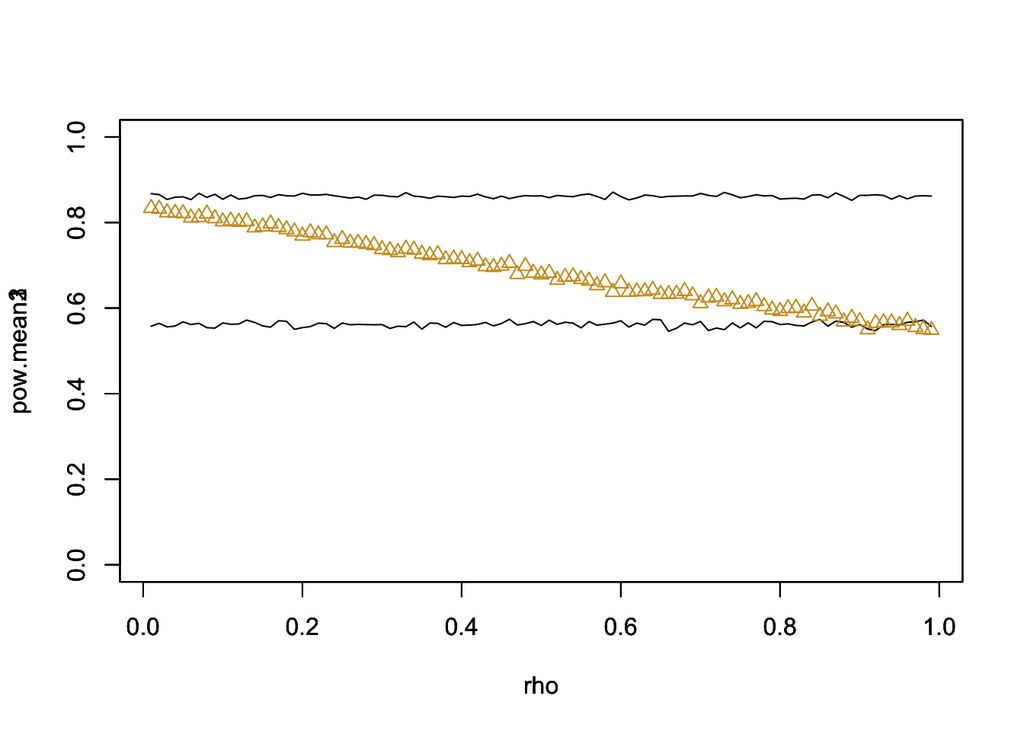

```r
# power of taking both measures into account
plot(rho,pow.mean1,ylim=c(0,1), type="l")
par(new = TRUE)
plot(rho,pow.mean2,ylim=c(0,1), type="l")
par(new = TRUE)
plot(rho,pow.mean3,ylim=c(0,1), type="p", col = "goldenrod3", pch = 2)
```

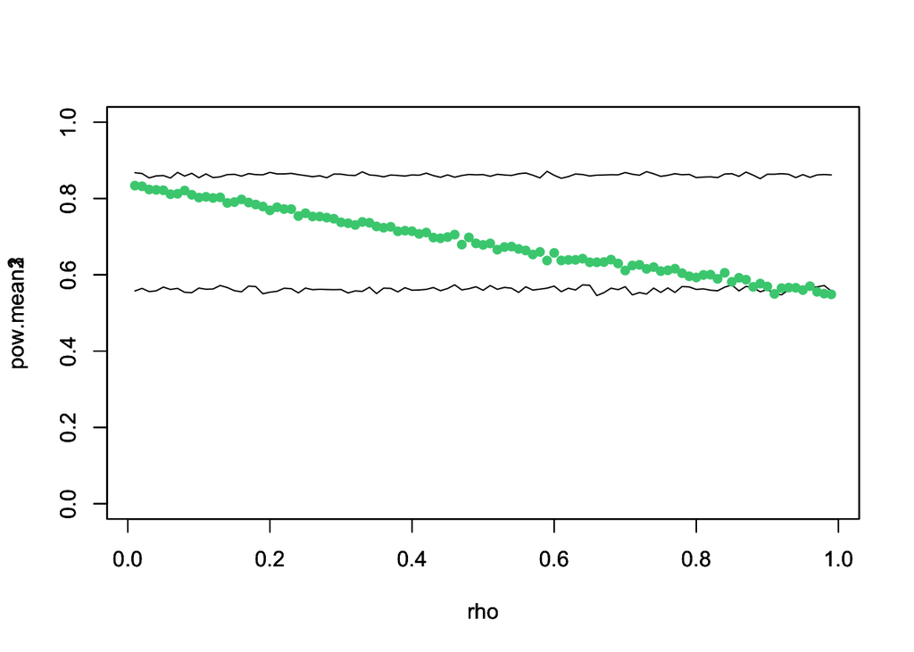

```r
# power of using the average
plot(rho,pow.mean1,ylim=c(0,1), type="l")
par(new = TRUE)
plot(rho,pow.mean2,ylim=c(0,1), type="l")
par(new = TRUE)
plot(rho,pow.mean3,ylim=c(0,1), type="p", col = "seagreen3", pch = 16)
```

If we overlay both plots we see that there is a lot of overlap. This can also be demonstrated by looking at the results that are exactly the same.

```r
table(pow.mean3==pow.mean4)
```

```
##
## FALSE  TRUE
##    35    64
```

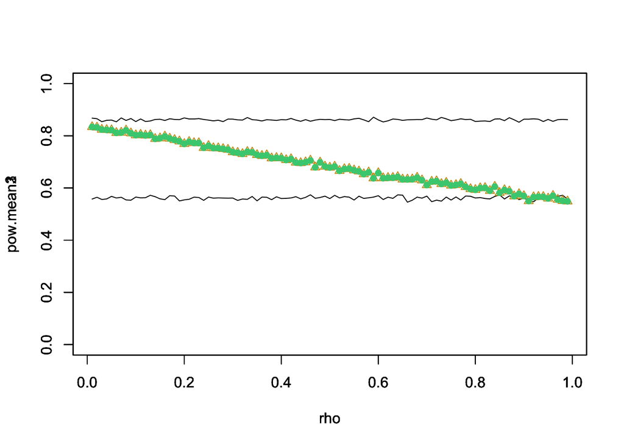

```r
# Overlap of both plots
plot(rho,pow.mean1,ylim=c(0,1), type="l")
par(new = TRUE)
plot(rho,pow.mean2,ylim=c(0,1), type="l")
par(new = TRUE)
plot(rho,pow.mean3,ylim=c(0,1), type="p", col = "goldenrod3", pch = 2)
par(new = TRUE)
plot(rho,pow.mean3,ylim=c(0,1), type="p", col = "seagreen3", pch = 16)
```